# Why does ha make hot but hoo make cold

[figure not shown]

```python
from IPython.display import Image
Image(filename='hooha_tweet.jpg')
```

When you look at this twitter thread (or other similar threads around the internet like [this Quora one](https://www.quora.com/Why-is-your-breath-warm-when-you-say-haaah-but-cold-when-you-say-whooh)), most explanations rely on one of two "effects" from fluid dynamics: (A) the **Venturi effect** (also refered to as pressure drops or just "expansion") or (B) **entrainment**, or a combination of the two effects. In this notebook I'd like to settle the matter by calculating how much of a temperature drop you can get from these effects. The tl;dr is that entrainment's cooling effects are an order of magnitude stronger than the Venturi effect (I'm not even sure if the Venturi effect will produce **any** cooling actually).

## The Venturi effect / over-pressured expansion / it's just PV = NRT

This explanation correctly points out that the air escaping from your mouth when you "hoo" is moving faster than when you "ha". The Venturi effect is just a fancy name for fact that, in a pipe with steady fluid flow, if you have a wide part of the pipe followed by a narrow part of pipe then the pressure will be higher in the wide part than the narrow part. You can see how this works with the mouth (wide part) and the lips (narrow part) by using basic fluid dynamics (you can start with the Bernoulli equation or the momentum equation, whatever you prefer) \begin{align} P_{mouth} - P_{lips} & = \frac{1}{2}\rho (v_{lips}^2 - v_{mouth}^2) . \\ \end{align}

which can be re-arranged to discover the temperature difference between the air in the high pressure region upstream of your mouth (which should be close to body temperature) and the lower pressure region just outside your mouth/lips, which will be about atmospheric pressure because it will be in equilibrium with the environment. If we combine the above with the ideal gas law (PV = nkT) and also note that $v_{mouth}^2 << v_{lips}^2$ so that we can say that $v_{lips}^2 - v_{mouth}^2 \approx v_{lips}^2$, then we get \begin{align} T_{mouth} - T_{\rm outside} & = \frac{\rho v_{lips}^2}{2nk}\\ T_{\rm outside} &= T_{mouth} - \frac{\rho v_{lips}^2}{2nk}. \end{align} If I had to guess the air speed of a "hoo", I'd say it's around 10 meters/second. In general the maximum air velocity a human can push out of their mouth is around 50 meters/second according to [this Quora thread](https://qr.ae/pNySU6). When you plug in these numbers, it appears this effect can only explain a Temperature drop of a fraction of a Celsius degree, and at maximum can explain a drop of a few degrees Celsius.

The air speed of the "ha" is of course slower (say less than 1 m/s) so it will be close to body temperature. So it the Venturi effect might be able to explain why "hoo" and "ha" are a fraction of a degree different.

Besides the fact that the Venturi can only explain a cooling of a fraction of degree, a major problem with the Venturi effect explaining the "hoo" "ha" temperature difference is the assumption that $T_{mouth} = $ body temperature. When you contract your lungs/diaphram, the resulting pressure for a parcel of air will increase and cause the temperature of that parcel of air in your lungs (soon to be mouth) to *increase*. Then when that parcel of air reaches your lips, the pressure will drop again to atmospheric pressure, resulting in no net change to the temperature. The main way I can see to get around this problem is to assume that the air parcel, somewhere between the lungs and mouth, equilibriates with your body's temperature (and therefore drops), and then drops again when it reaches your lips. I think the odds are that in the fraction of a second during which air parcels traverse the distance from your lungs to your lips, not enough heat is transfered for that equilibrium to be reached.

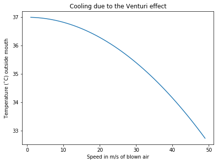

```python
n_air = 0.025e27 # m^-3
rho_air = 1.225 # kg / m^3, moist air density is 1.2, so not much difference
k = 1.38e-23 # m^2 kg s^-2 K^-1
T_mouth = 37 # body temperature in celsius.
# note Celsius and Kelvin are same since we are Celsius degrees are the same size as Kelvin.

v_room = np.arange(1, 50)
T_outside = T_mouth - rho_air * v_room ** 2 / (2 * n_air * k)

import matplotlib.pyplot as plt
fig, ax = plt.subplots(figsize=(7,5))
ax.plot(v_room, T_outside);
ax.set_ylabel("Temperature ($^{\circ}$C) outside mouth");
ax.set_xlabel("Speed in m/s of blown air");
ax.set_title("Cooling due to the Venturi effect");
```

## Entrainment

When you blow, or make "hoo" or "ha", a turbulent jet of air escapes from your mouth. It turns out these kinds of jets have a few universal properties that makes it easy to calculate how the jet's average temperature decreases with distance. Most importantly, all round turbulent jets have a half opening angle of 11.8 degrees. This observation and a few other assumptions, when combined with conservation of momentum, allow you to derive quite a few interesting things about these kinds of jets.

### Here's what an 11.8 degree half opening angle looks like on a real image of a person's breath "jet", as illuminated by vaping.

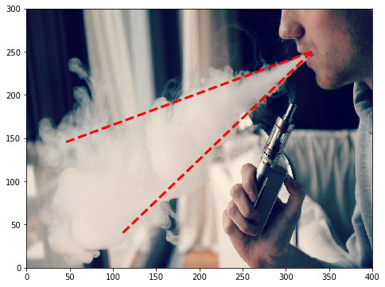

```python
import numpy as np

# Create a 11.8 degree angle with respect the x-axis
theta = 11.8 * np.pi / 180
slope = np.tan(theta)
x = np.arange(0,1,0.01)
y = slope * x

# Rotate and translate the 11.8 degree angle so it visually lines up with the image.
# this is to see if the 11.8 degrees angle (which we don't adjust!) seems to fit.
# Rotate both the origin line and it' mirror about the y-axis
theta = 212
stretch = 300
origin_x, origin_y = -330, -250
from scipy.spatial.transform import Rotation as R
r = R.from_euler('z', theta, degrees=True)
r.as_matrix()
vec = np.array([1,0,0])
r.apply(vec)

mymat_pos = np.concatenate((x.reshape(-1,1), y.reshape(-1,1),
                            np.zeros((len(x),1))), axis=1)
mymat_neg = np.concatenate((x.reshape(-1,1), -1*y.reshape(-1,1),
                            np.zeros((len(x),1))), axis=1)
mymat_rot_pos = r.apply(mymat_pos)
mymat_rot_neg = r.apply(mymat_neg)
newx_pos = mymat_rot_pos[:,0]
newy_pos = mymat_rot_pos[:,1]
newx_neg = mymat_rot_neg[:,0]
newy_neg = mymat_rot_neg[:,1]

fig, ax = plt.subplots(figsize=(8,6))
img = plt.imread("smokejet_vaping360.jpg");
ax.imshow(img, extent=[0, 400, 0, 300]);

ax.plot(newx_pos*stretch - origin_x,
        newy_pos*stretch - origin_y, "--", color="red", linewidth=3);
ax.plot(newx_neg*stretch - origin_x,
        newy_neg*stretch - origin_y, "--", color="red", linewidth=3);
```

image credit [vaping360.com](https://vaping360.com/)

When the jet of air escapes your mouth, regardless whether you're "hoo"-ing or "ha"-ing, the driving force is no longer present and the jet is coasting. (The following tracks this [this discussion of round turbulent jets closely.](http://www.dartmouth.edu/~cushman/books/EFM/chap9.pdf)) This means that the momentum flux in the jet will be the same at the "nozzle" of your mouth, which we'll say has a diameter d.  
\begin{align} {\rm MomentumFlux} &= (\rho_{air}u_{\rm lips}) u_{\rm lips} A_{nozzle} \\ & = (\rho_{\rm air}u(z)) u(z) A_{\rm jet} \\ \end{align} Here $u_{\rm lips}$ is the air speed just at your lips, $u(z)$ is the average air speed in the jet a distance $z$ from your mouth. If we replace the Area of your pursed lips when you're saying "ooh" or "ah" with $A_{nozzle} = \pi d^2$, and the cross-sectional area of the jet as $A_{jet} = \pi R^2$, and note that the 11.8 degree half opening angle implies that $R(z) = z \tan (\theta) \approx z/5$, then we find \begin{align} u(z) = \frac{5 u_{\rm lips} d}{z} \end{align} Now we can calculate the mass flux through the jet, Q(z) as: \begin{align} Q(z) &= \rho u(z) A(z) \\ & \propto \rho u_{\rm lips} d z \end{align} The fact that the mass flux in the jet, $Q$, grows with distance from your mouth, $z$, is *precisely* what we mean by entrainment. What's so cool about turbulent round jets is that we can actually *calculate* this quantity. To be precise, to get at the entrained material, we would need to subtract out the original air escaping from your mouth, which is we'll call $Q_0$.

To calculate the temperature, we'll need to make a few assumptions. As the turbulent mixing proceeds in the jet, at a given distance away from the mouth, the effective temperature of the mixed material will the be mass density weighted average of the entrained material (room temperature, $T_{\rm room}\sim 20^{\circ}$C) and the original mouth air (body temperature, $T_{\rm mouth} \sim 37^{\circ}$C), which is precisely what you expect when 2 materials with differnt temperatures and similar heat capacities mix and come to thermal equilibrium. \begin{align} T(z) &= \frac{{\rm originalMassFlux}\times T_{\rm mouth} + {\rm entrainedMassFlux}\times T_{\rm room}}{{\rm originalMassFlux} + {\rm entrainedMassFlux}} \\ &= \frac{Q_0T_{\rm mouth} + (Q(z) - Q_0)T_{\rm room}}{Q(z)} \end{align} Now that we almost getting to producing numbers, instead of the using the estimates of mass flux I derived above, I'll use the calculations from [here](http://www.dartmouth.edu/~cushman/books/EFM/chap9.pdf), which makes assumptions about Gaussian velocity profiles across the jet, and integrate over this profile to calculate fluxes to find that $Q(z) = \frac{\pi}{10} d u_{\rm lips} z$. Moreover, the mass flux will at the lips will the same equation, except where $z$ is set to $2.5d$, which is known as the virtual correction to account for the lips not being the vertex of the jet's cone. This implies that $Q_0 = \pi/4 d^2 u_{\rm lips}$, which yields \begin{align} T(z) - T_{\rm room} &= \frac{10d}{4z}(T_{\rm body} - T_{\rm room}) \end{align} With that calculation done we can now get some numbers.

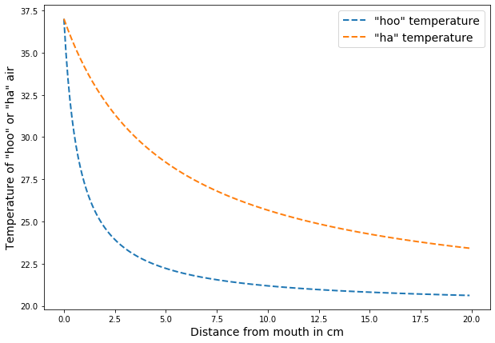

```python
z = np.arange(0, 20, 0.1)
d_hoo = 0.3 # when your mouth/nozzle is small
d_ha = 2 # when your mouth/nozzle is large
T_body = 37
T_room = 20

# T(z), with the virtual correction applied where the mouth (nozzle) is located
# at z = 2.5d from the origin of the jet cone.
T_hoo = 10 * d_hoo/(4 * (z+2.5*d_hoo)) * (T_body - T_room) + T_room
T_ha = 10 * d_ha/(4 * (z+2.5*d_ha)) * (T_body - T_room) + T_room

fig, ax = plt.subplots(figsize=(10,7))
ax.plot(z, T_hoo, '--', label = '"hoo" temperature', linewidth=2)
ax.plot(z, T_ha, '--', label='"ha" temperature', linewidth=2)
ax.set_xlabel("Distance from mouth in cm", fontsize=14)
ax.set_ylabel('Temperature of "hoo" or "ha" air', fontsize=14)
plt.legend(fontsize=14);
```

This plot demonstrates that entrainment perfectly captures what's going on when we "hoo" vs "ha". When we "hoo", or just blow with our lips pursed like we're cooling our coffee, the air close to our mouth (within a couple cm) is indeed warm if we feel it. Further away, it is "cold", where much of the "coldness" is driven by evaporative cooling ("wind chill") since in reality it is just close to room temperature.